# Break-down Plots for Instance Level Attributions

Code snippets for R

Przemysław Biecek

for DALEX 1.0

In this section, we use an `DALEX::predict_parts()` function for calculation of Break Down plots.

If you want learn more about Break Down plots read https://pbiecek.github.io/ema/breakDown.html.

# Prepare data

In this example we will use the titanic data. It has few variables that are easy to understand. The `titanic_imputed` dataset from `DALEX` package has imputed missing values. Find more about the data https://pbiecek.github.io/ema/dataSetsIntro.html#TitanicDataset

```r
library("DALEX")
head(titanic_imputed)
```

```
##   gender age class    embarked  fare sibsp parch survived
## 1   male  42   3rd Southampton  7.11     0     0        0
## 2   male  13   3rd Southampton 20.05     0     2        0
## 3   male  16   3rd Southampton 20.05     1     1        0
## 4 female  39   3rd Southampton 20.05     1     1        1
## 5 female  16   3rd Southampton  7.13     0     0        1
## 6   male  25   3rd Southampton  7.13     0     0        1
```

# Train a model

Here we use `ranger` library to train a classification random forest model.

```r
library("ranger")
titanic_rf <- ranger(survived ~ class + gender + age + sibsp +
         parch + fare + embarked, data = titanic_imputed,
         probability = TRUE,
         classification = TRUE)
titanic_rf
```

```
## Ranger result
##
## Call:
##  ranger(survived ~ class + gender + age + sibsp + parch + fare +      embarked, data = titanic_imputed, probability = TRUE, classification = TRUE)
##
## Type:                             Probability estimation
## Number of trees:                  500
## Sample size:                      2207
## Number of independent variables:  7
## Mtry:                             2
## Target node size:                 10
## Variable importance mode:         none
## Splitrule:                        gini
## OOB prediction error (Brier s.):  0.1417578
```

# Prepare an explainer

Different models have different structures. We use `DALEX::explain()` function to create an uniform interface for the model

```r
library("DALEX")
titanic_ex <- explain(titanic_rf,
                data  = titanic_imputed,
                y     = titanic_imputed$survived,
                label = "Regression Forest for Titanic")
```

```
## Preparation of a new explainer is initiated
##   -> model label       :  Regression Forest for Titanic
##   -> data              :  2207  rows  8  cols
##   -> target variable   :  2207  values
##   -> data              :  A column identical to the target variable `y` has been found in the `data`.  (  WARNING  )
##   -> data              :  It is highly recommended to pass `data` without the target variable column
##   -> model_info        :  package ranger , ver. 0.11.2 , task classification (  default  )
##   -> predict function  :  yhat.ranger  will be used (  default  )
##   -> predicted values  :  numerical, min =  0.01605066 , mean =  0.3217188 , max =  0.9903434
##   -> residual function :  difference between y and yhat (  default  )
##   -> residuals         :  numerical, min =  -0.7937978 , mean =  0.0004379683 , max =  0.8826515
##   A new explainer has been created!
```

# Prepare an instance

For instance level explanations we need an observation for which we can generate explanation.

Let’s create a data.frame with a single row that corresponds to 8 years old boy from 1st class.

```r
johny_d <- data.frame(
            class = factor("1st", levels = c("1st", "2nd", "3rd", "deck crew",
                        "engineering crew", "restaurant staff", "victualling crew")),
            gender = factor("male", levels = c("female", "male")),
            age = 8,
            sibsp = 0,
            parch = 0,
            fare = 72,
            embarked = factor("Southampton", levels = c("Belfast",
                        "Cherbourg","Queenstown","Southampton")))
```

The predicted survival for `johny_d` is

```r
predict(titanic_ex, johny_d)
```

```
## [1] 0.4656422
```

# Break-down plots with `predict_parts()`

The `DALEX::predict_parts()` function calculates the variable attributions for a selected model and the instance of interest.

The result is a data frame containing the calculated attributions. In the simplest call, the function requires only three arguments:

- the model explainer,
- the data frame with the instance of interest and
- the method for calculation of variable attribution, by default `break_down`.

```r
bd_rf <- predict_parts(titanic_ex,
                 new_observation = johny_d,
                 type = "break_down")
bd_rf
```

```
##                                                       contribution
## Regression Forest for Titanic: intercept                     0.322
## Regression Forest for Titanic: age = 8                       0.204
## Regression Forest for Titanic: class = 1st                   0.101
## Regression Forest for Titanic: gender = male                -0.056
## Regression Forest for Titanic: fare = 72                    -0.070
## Regression Forest for Titanic: sibsp = 0                     0.001
## Regression Forest for Titanic: embarked = Southampton       -0.008
## Regression Forest for Titanic: parch = 0                    -0.028
## Regression Forest for Titanic: prediction                    0.466
```

Applying the generic `plot()` function to the object resulting from the application of the `variable_attribution()` function creates a BD plot.

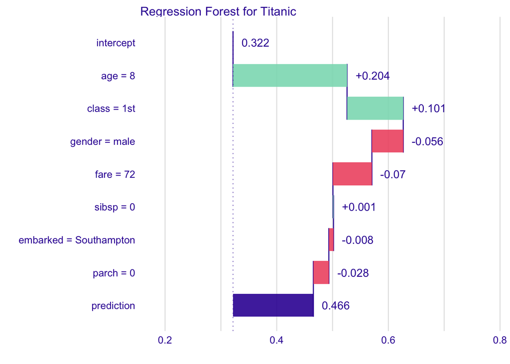

```r
plot(bd_rf)
```

It is the `ggplot2` object, so one can modify it as any other `ggplot2` object.

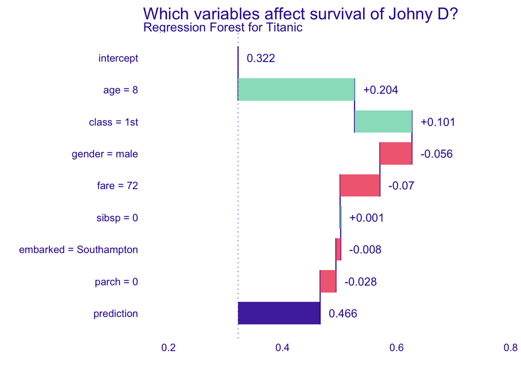

```r
library("ggplot2")
plot(bd_rf) +
  ggtitle("Which variables affect survival of Johny D?") +
  theme(panel.grid = element_blank())
```

# Advanced use of the `predict_parts()`

The function `predict_parts()` allows more arguments. The most commonly used are:

- `x` - a wrapper over a model created with function `DALEX::explain()`,
- `new_observation` - an observation to be explained is should be a data frame with structure that matches the training data,
- `order` - a vector of characters (column names) or integers (column indexes) that specify order of explanatory variables that is used for computing the variable-importance measures. If not specified (default), then a one-step heuristic is used to determine the order,
- `keep_distributions` - a logical value; if `TRUE`, then additional diagnostic information about conditional distributions is stored in the resulting object and can be plotted with the generic `plot()` function.

In what follows we illustrate the use of the arguments.

First, we will specify the ordering of the explanatory variables. Toward this end we can use integer indexes or variable names. The latter option is preferable in most cases because of transparency. .

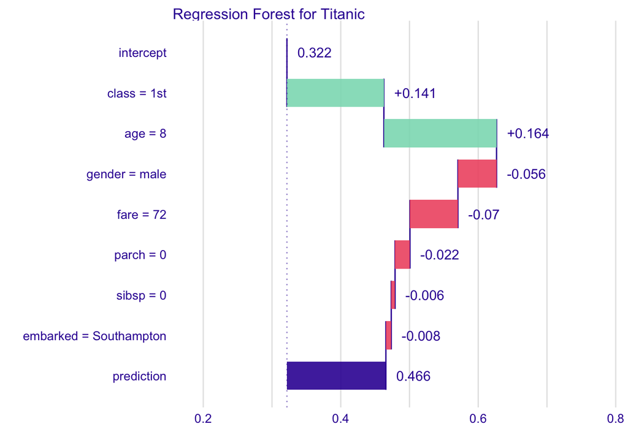

```r
bd_rf_order <- predict_parts(titanic_ex,
         new_observation = johny_d,
         type = "break_down",
         order = c("class", "age", "gender", "fare", "parch",
                           "sibsp", "embarked"))

plot(bd_rf_order)
```

We can use the`keep_distributions = TRUE` argument to enrich the resulting object with additional information about conditional distributions. Subsequently, we can apply the `plot_distributions = TRUE` argument in the `plot()` function to present the distributions as violin plots.

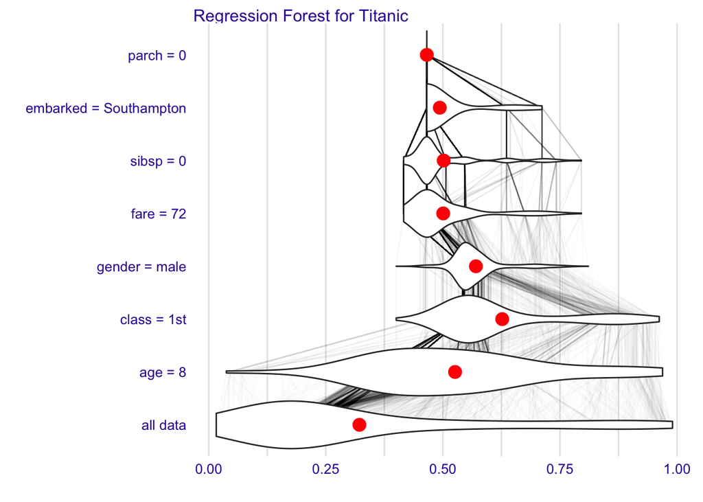

```r
bd_rf_distr <- variable_attribution(titanic_ex,
          new_observation = johny_d,
          type = "break_down",
          keep_distributions = TRUE)

plot(bd_rf_distr, plot_distributions = TRUE)
```

We can also limit the number of variables in the plot to the `max_features` most important.

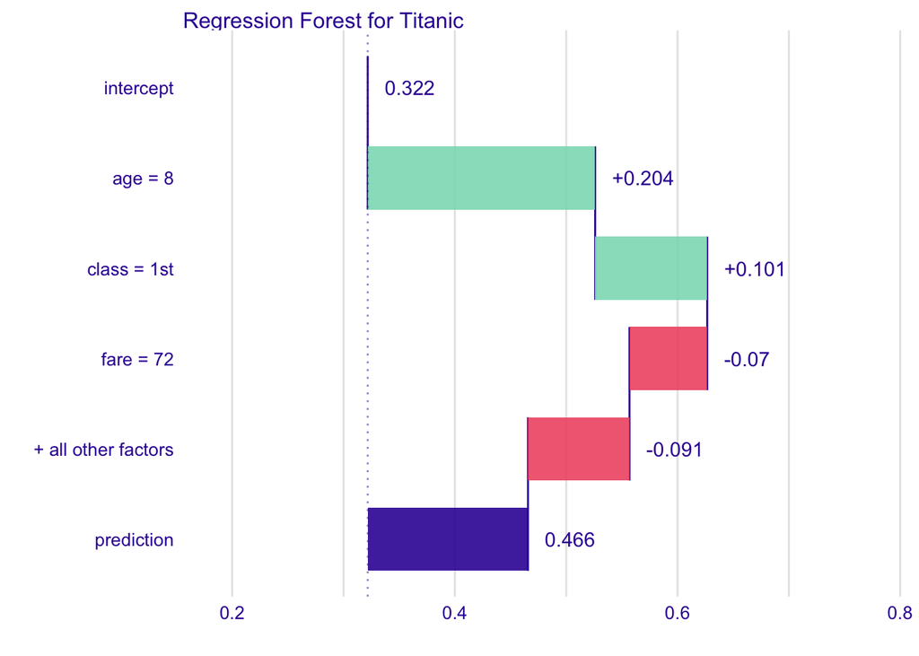

```r
bd_rf <- variable_attribution(titanic_ex,
          new_observation = johny_d,
          type = "break_down")

plot(bd_rf, max_features = 3)
```